# TASK 4_CREDIT RISK ASSESSMENT & COST-BASED THRESHOLD OPTIMIZATION

## PROBLEM STATEMENT AND OBJECTIVE

## Problem Statement

Financial institutions face substantial losses when borrowers default on loans. Accurately identifying high-risk applicants before loan approval is crucial for minimizing financial losses and improving lending decisions. Traditional evaluation metrics alone may not adequately reflect the business consequences of incorrect classifications.

## Objective

The objectives of this project are to:

- Predict loan default risk using machine learning.
- Clean and preprocess credit risk data.
- Compare Logistic Regression and CatBoost models.
- Evaluate model performance using classification metrics.
- Define business costs for misclassifications.
- Optimize the classification threshold to minimize total business cost.
- Generate actionable recommendations for credit risk management.

## DATASET DESCRIPTION

## Dataset Name

Credit Risk Dataset

## Dataset Overview

The Credit Risk Dataset contains information about loan applicants, including demographic characteristics, financial history, employment status, loan details, and credit behavior.

The primary objective of the dataset is to predict whether a borrower is likely to default on a loan. This enables financial institutions to make informed lending decisions, reduce financial losses, and improve risk management strategies.

The target variable is loan_status, which indicates whether a borrower defaulted on a loan.

## Features Description

| Feature | Description |
| --- | --- |
| person_age | Age of the borrower |
| person_income | Annual income of the borrower |
| person_home_ownership | Home ownership status (Rent, Mortgage, Own, Other) |
| person_emp_length | Employment length in years |
| loan_intent | Purpose of the loan |
| loan_grade | Loan risk grade assigned by lender |
| loan_amnt | Amount of loan requested |
| loan_int_rate | Loan interest rate |
| loan_percent_income | Percentage of income allocated to loan repayment |
| cb_person_default_on_file | Previous default history (Y/N) |
| cb_person_cred_hist_length | Length of credit history |
| loan_status | Target variable indicating default status |

## Target Variable

## loan_status

| Value | Meaning |
| --- | --- |
| 0 | Non-Default |
| 1 | Default |

## DATASET LOADING

```python
# Import Libraries

# Data Manipulation
import pandas as pd
import numpy as np

# Visualization
import matplotlib.pyplot as plt
import seaborn as sns

# Preprocessing
from sklearn.preprocessing import StandardScaler
from sklearn.model_selection import train_test_split

# Models
from sklearn.linear_model import LogisticRegression
from catboost import CatBoostClassifier

# Evaluation
from sklearn.metrics import (
    confusion_matrix,
    classification_report,
    roc_curve,
    roc_auc_score,
    f1_score)

import warnings
warnings.filterwarnings('ignore')
```

```python
# Load dataset
credit = pd.read_csv("credit_risk_dataset.csv")
```

```python
# Display dataset shape
print("Shape:", credit.shape)
```

```
Shape: (32581, 12)
```

```python
# View first five rows
credit.head()
```

|  | person_age | person_income | person_home_ownership | person_emp_length | loan_intent | loan_grade | loan_amnt | loan_int_rate | loan_status | loan_percent_income | cb_person_default_on_file | cb_person_cred_hist_length |
| --- | --- | --- | --- | --- | --- | --- | --- | --- | --- | --- | --- | --- |
| 0 | 22 | 59000 | RENT | 123.0 | PERSONAL | D | 35000 | 16.02 | 1 | 0.59 | Y | 3 |
| 1 | 21 | 9600 | OWN | 5.0 | EDUCATION | B | 1000 | 11.14 | 0 | 0.10 | N | 2 |
| 2 | 25 | 9600 | MORTGAGE | 1.0 | MEDICAL | C | 5500 | 12.87 | 1 | 0.57 | N | 3 |
| 3 | 23 | 65500 | RENT | 4.0 | MEDICAL | C | 35000 | 15.23 | 1 | 0.53 | N | 2 |
| 4 | 24 | 54400 | RENT | 8.0 | MEDICAL | C | 35000 | 14.27 | 1 | 0.55 | Y | 4 |

```python
# View last five rows
credit.tail()
```

|  | person_age | person_income | person_home_ownership | person_emp_length | loan_intent | loan_grade | loan_amnt | loan_int_rate | loan_status | loan_percent_income | cb_person_default_on_file | cb_person_cred_hist_length |
| --- | --- | --- | --- | --- | --- | --- | --- | --- | --- | --- | --- | --- |
| 32576 | 57 | 53000 | MORTGAGE | 1.0 | PERSONAL | C | 5800 | 13.16 | 0 | 0.11 | N | 30 |
| 32577 | 54 | 120000 | MORTGAGE | 4.0 | PERSONAL | A | 17625 | 7.49 | 0 | 0.15 | N | 19 |
| 32578 | 65 | 76000 | RENT | 3.0 | HOMEIMPROVEMENT | B | 35000 | 10.99 | 1 | 0.46 | N | 28 |
| 32579 | 56 | 150000 | MORTGAGE | 5.0 | PERSONAL | B | 15000 | 11.48 | 0 | 0.10 | N | 26 |
| 32580 | 66 | 42000 | RENT | 2.0 | MEDICAL | B | 6475 | 9.99 | 0 | 0.15 | N | 30 |

```python
# Check data types
credit.info()
```

```
<class 'pandas.DataFrame'>
RangeIndex: 32581 entries, 0 to 32580
Data columns (total 12 columns):
 #   Column                      Non-Null Count  Dtype
---  ------                      --------------  -----
 0   person_age                  32581 non-null  int64
 1   person_income               32581 non-null  int64
 2   person_home_ownership       32581 non-null  str
 3   person_emp_length           31686 non-null  float64
 4   loan_intent                 32581 non-null  str
 5   loan_grade                  32581 non-null  str
 6   loan_amnt                   32581 non-null  int64
 7   loan_int_rate               29465 non-null  float64
 8   loan_status                 32581 non-null  int64
 9   loan_percent_income         32581 non-null  float64
 10  cb_person_default_on_file   32581 non-null  str
 11  cb_person_cred_hist_length  32581 non-null  int64
dtypes: float64(3), int64(5), str(4)
memory usage: 3.5 MB
```

```python
# Summary statistics
credit.describe()
```

|  | person_age | person_income | person_emp_length | loan_amnt | loan_int_rate | loan_status | loan_percent_income | cb_person_cred_hist_length |
| --- | --- | --- | --- | --- | --- | --- | --- | --- |
| count | 32581.000000 | 3.258100e+04 | 31686.000000 | 32581.000000 | 29465.000000 | 32581.000000 | 32581.000000 | 32581.000000 |
| mean | 27.734600 | 6.607485e+04 | 4.789686 | 9589.371106 | 11.011695 | 0.218164 | 0.170203 | 5.804211 |
| std | 6.348078 | 6.198312e+04 | 4.142630 | 6322.086646 | 3.240459 | 0.413006 | 0.106782 | 4.055001 |
| min | 20.000000 | 4.000000e+03 | 0.000000 | 500.000000 | 5.420000 | 0.000000 | 0.000000 | 2.000000 |
| 25% | 23.000000 | 3.850000e+04 | 2.000000 | 5000.000000 | 7.900000 | 0.000000 | 0.090000 | 3.000000 |
| 50% | 26.000000 | 5.500000e+04 | 4.000000 | 8000.000000 | 10.990000 | 0.000000 | 0.150000 | 4.000000 |
| 75% | 30.000000 | 7.920000e+04 | 7.000000 | 12200.000000 | 13.470000 | 0.000000 | 0.230000 | 8.000000 |
| max | 144.000000 | 6.000000e+06 | 123.000000 | 35000.000000 | 23.220000 | 1.000000 | 0.830000 | 30.000000 |

## DATA CLEANING AND PREPROCESSING

```python
# Check missing values
credit.isnull().sum()
```

```
person_age                       0
person_income                    0
person_home_ownership            0
person_emp_length              895
loan_intent                      0
loan_grade                       0
loan_amnt                        0
loan_int_rate                 3116
loan_status                      0
loan_percent_income              0
cb_person_default_on_file        0
cb_person_cred_hist_length       0
dtype: int64
```

```python
# Handle missing values
for col in credit.select_dtypes(include=np.number):
    credit[col] = credit[col].fillna(credit[col].median())
```

```python
# Check duplicates
credit.duplicated().sum()
```

```
np.int64(165)
```

```python
# Remove duplicates
credit.drop_duplicates(inplace=True)
print("New Shape:", credit.shape)
```

```
New Shape: (32416, 12)
```

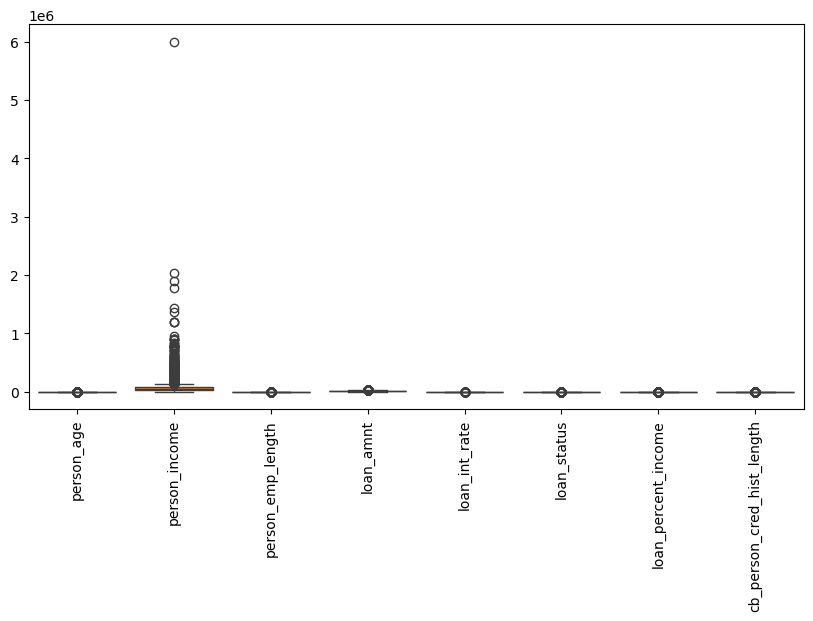

```python
# Outlier detection
plt.figure(figsize=(10,5))

sns.boxplot(data=credit)

plt.xticks(rotation=90)

plt.show()
```

## EXPLORATORY DATA ANALYSIS (EDA)

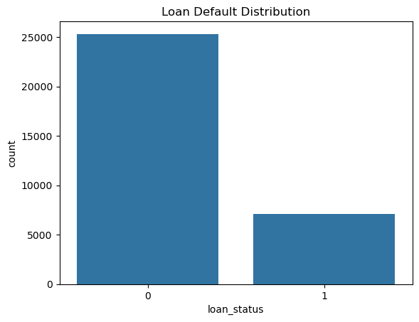

```python
# Loan Default Distribution
sns.countplot(x='loan_status',
              data=credit)

plt.title("Loan Default Distribution")

plt.show()
```

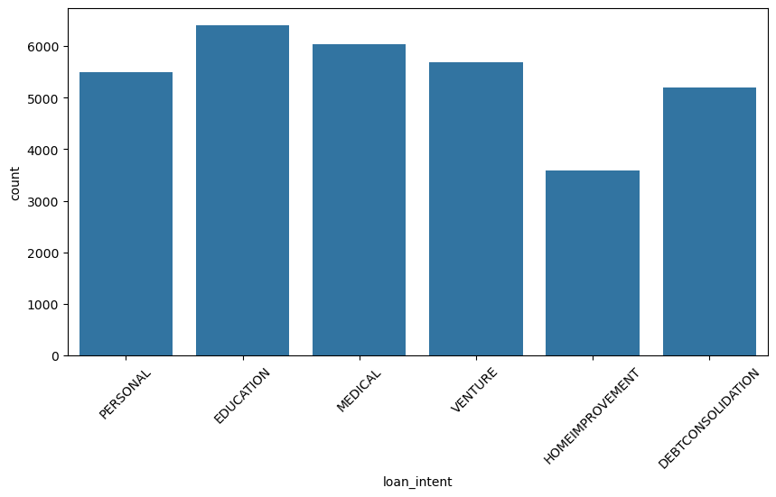

```python
# Loan Intent Distribution
plt.figure(figsize=(10,5))

sns.countplot(x='loan_intent',
              data=credit)

plt.xticks(rotation=45)

plt.show()
```

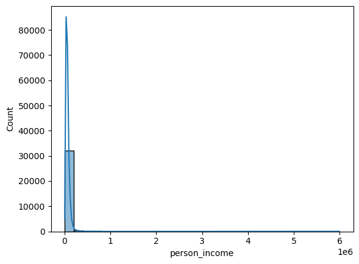

```python
# Income Distribution
sns.histplot(credit['person_income'],
             bins=30,
             kde=True)

plt.show()
```

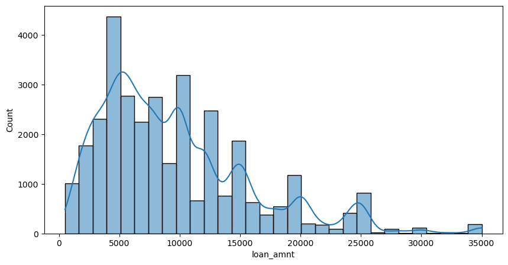

```python
# Loan Amount Distribution
plt.figure(figsize=(10,5))

sns.histplot(credit['loan_amnt'],
             bins=30,
             kde=True)

plt.show()
```

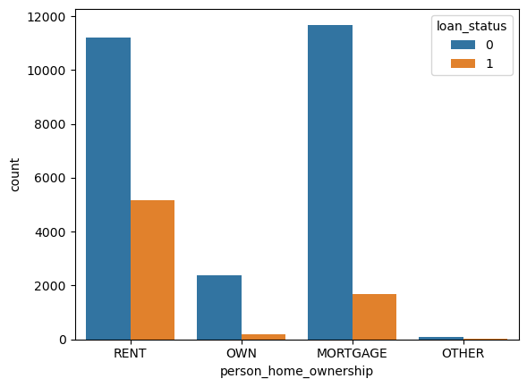

```python
# Home Ownership Analysis
sns.countplot(x='person_home_ownership',
              hue='loan_status',
              data=credit)

plt.show()
```

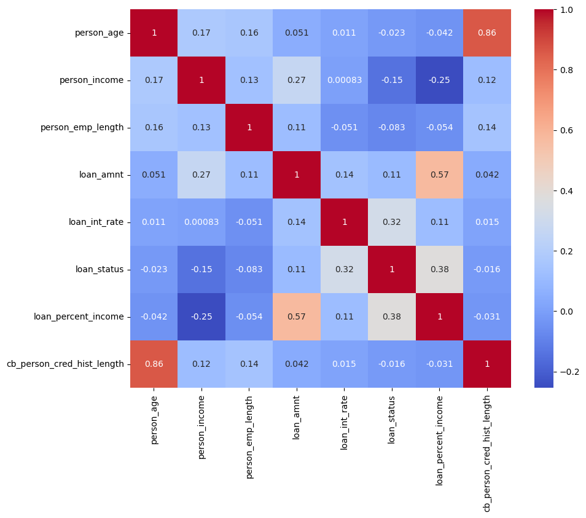

```python
# Correlation Heatmap
num_cols = credit.select_dtypes(include=np.number)

plt.figure(figsize=(10,8))

sns.heatmap(num_cols.corr(),
            annot=True,
            cmap='coolwarm')

plt.show()
```

## FEATURE ENGINEERING AND ENCODING

```python
# Encode Categorical Variables
credit_encoded = pd.get_dummies(credit,
                                drop_first=True)
```

```python
# Features and Target
X = credit_encoded.drop('loan_status',
                        axis=1)

y = credit_encoded['loan_status']
```

```python
# Train-Test Split
X_train, X_test, y_train, y_test = train_test_split(X,
                                                    y,
                                                    test_size=0.2,
                                                    random_state=42,
                                                    stratify=y)
```

```python
# Scaling
scaler = StandardScaler()

X_train_scaled = scaler.fit_transform(X_train)

X_test_scaled = scaler.transform(X_test)
```

## MODEL BUILDING

## Model 1: Logistic Regression

```python
# Train Model
lr = LogisticRegression(max_iter=1000)

lr.fit(X_train_scaled,
       y_train)
```

```
LogisticRegression(max_iter=1000)
```

```python
# Prediction
lr_pred = lr.predict(X_test_scaled)

lr_prob = lr.predict_proba(X_test_scaled)[:,1]
```

## Model 2: CatBoost

```python
# Train Model
cat_model = CatBoostClassifier(verbose=0,
                               random_state=42)

cat_model.fit(X_train,
              y_train)
```

```
CatBoostClassifier(random_state=42, verbose=0)
```

```python
# Prediction
cat_pred = cat_model.predict(X_test)

cat_prob = cat_model.predict_proba(X_test)[:,1]
```

## MODEL EVALUATION

## Logistic Regression Evaluation

```python
# Classification Report
print(classification_report(y_test,
                            lr_pred))
```

```
              precision    recall  f1-score   support

           0       0.89      0.95      0.92      5066
           1       0.77      0.57      0.65      1418

    accuracy                           0.87      6484
   macro avg       0.83      0.76      0.79      6484
weighted avg       0.86      0.87      0.86      6484
```

```python
# F1 Score
print("F1 Score:",
      f1_score(y_test, lr_pred))
```

```
F1 Score: 0.6547376982513217
```

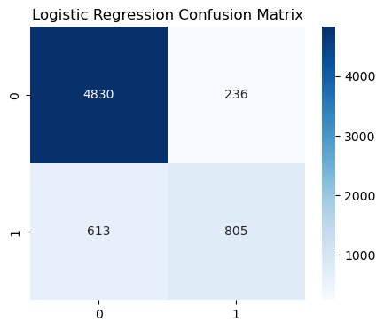

```python
# Confusion Matrix
cm_lr = confusion_matrix(y_test,
                         lr_pred)

plt.figure(figsize=(5,4))

sns.heatmap(cm_lr,
            annot=True,
            fmt='d',
            cmap='Blues')

plt.title("Logistic Regression Confusion Matrix")

plt.show()
```

## CatBoost Evaluation

```python
# Classification Report
print(classification_report(y_test,
                            cat_pred))
```

```
              precision    recall  f1-score   support

           0       0.93      1.00      0.96      5066
           1       0.98      0.73      0.84      1418

    accuracy                           0.94      6484
   macro avg       0.96      0.86      0.90      6484
weighted avg       0.94      0.94      0.94      6484
```

```python
# F1 Score
print("F1 Score:",
      f1_score(y_test, cat_pred))
```

```
F1 Score: 0.8390480032271077
```

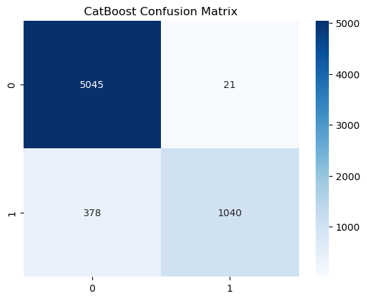

```python
# Confusion Matrix
cm = confusion_matrix(y_test,
                      cat_pred)

sns.heatmap(cm,
            annot=True,
            fmt='d',
            cmap='Blues')

plt.title("CatBoost Confusion Matrix")

plt.show()
```

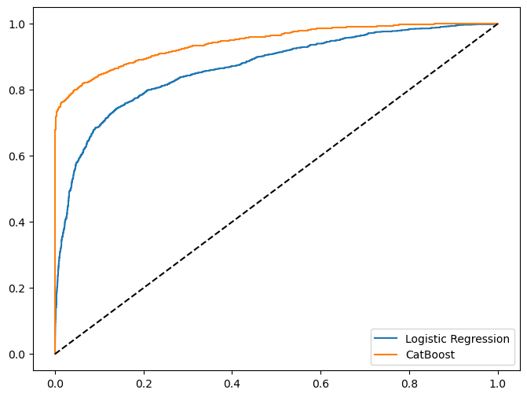

```python
# ROC Curve
fpr_lr, tpr_lr, _ = roc_curve(y_test,
                              lr_prob)

fpr_cat, tpr_cat, _ = roc_curve(y_test,
                                cat_prob)

plt.figure(figsize=(8,6))

plt.plot(fpr_lr,
         tpr_lr,
         label='Logistic Regression')

plt.plot(fpr_cat,
         tpr_cat,
         label='CatBoost')

plt.plot([0,1],[0,1],'k--')

plt.legend()

plt.show()
```

## BUSINESS COST ANALYSIS

```python
# Cost Definition
FP_COST = 1000
FN_COST = 10000
```

## Justification

- False Positive = Good borrower rejected
- False Negative = Defaulter approved

False negatives are significantly more expensive.

```python
# Threshold Optimization
thresholds = np.arange(0.1,
                       1.0,
                       0.01)

costs = []

for threshold in thresholds:

    pred = (cat_prob >= threshold).astype(int)

    tn, fp, fn, tp = confusion_matrix(y_test,
                                      pred).ravel()

    cost = (fp * FP_COST) + (fn * FN_COST)

    costs.append(cost)
```

```python
# Best Threshold
best_threshold = thresholds[np.argmin(costs)]

print("Best Threshold:",
      best_threshold)
```

```
Best Threshold: 0.1
```

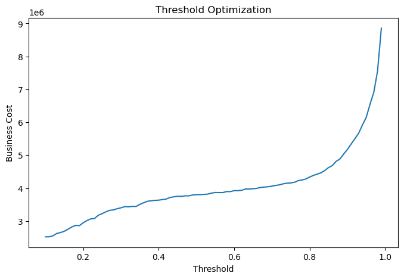

```python
# Cost Optimization Plot
plt.figure(figsize=(8,5))

plt.plot(thresholds,
         costs)

plt.xlabel("Threshold")

plt.ylabel("Business Cost")

plt.title("Threshold Optimization")

plt.show()
```

## BUSINESS INSIGHTS AND RECOMMENDATIONS

## Key Insights

## A. Loan Default Distribution

- The dataset is moderately imbalanced, with significantly more non-default loans than default loans.
- Most borrowers successfully repay their loans, while a smaller proportion represent high-risk customers.
- This imbalance highlights the importance of using metrics beyond accuracy when evaluating model performance.

## B. Borrower Characteristics

## 1. Income Distribution

- Most borrowers fall within lower to moderate income brackets.
- A small number of borrowers have exceptionally high incomes, creating a right-skewed distribution.
- Income alone does not fully explain default behavior, suggesting the need to consider multiple risk factors.

## C. Model Performance Insights

## 1. Logistic Regression

- Produced strong classification performance and serves as a highly interpretable baseline model.
- Successfully identified many default cases while maintaining reasonable precision.

## D. ROC Curve Analysis

- Both models performed significantly better than random classification.
- CatBoost maintained higher true positive rates across various thresholds. This suggests better identification of risky borrowers without excessively increasing false positives.

## Recommendations

1. Risk-Based Lending Strategy
   - Implement CatBoost as the primary credit risk model due to its stronger predictive performance.
   - Use risk scores to categorize applicants into low, medium, and high-risk groups.
2. Threshold Optimization
   - Adopt the optimized threshold identified through business cost analysis rather than relying on the default classification threshold.
   - Continuously monitor threshold performance as borrower behavior evolves.
3. Strengthen Credit Assessment

   Place greater emphasis on:
   - Previous default history
   - Credit history length
   - Loan-to-income ratio
   - Loan grade
4. Portfolio Risk Management
   - Apply enhanced review processes for high-risk borrowers.
   - Introduce risk-adjusted interest rates based on predicted default probabilities.
5. Model Monitoring
   - Retrain models periodically using updated borrower information.
   - Monitor performance drift to ensure sustained predictive accuracy.

## CONCLUSION

This project successfully developed machine learning models for credit risk prediction and business cost optimization. Following preprocessing, exploratory analysis, and feature engineering, Logistic Regression and CatBoost models were trained and evaluated.

CatBoost demonstrated superior predictive performance and achieved stronger discriminatory power than Logistic Regression. Business cost analysis further revealed that optimizing the classification threshold significantly reduces expected financial losses associated with poor lending decisions.

The results show that machine learning can enhance credit risk management by improving default prediction accuracy, supporting better lending decisions, and minimizing financial risk exposure.